# Homework 8

Sarah Morris

3/31/2021

#### Homework 8: Creating Fake Data Sets to Explore Hypotheses

##### I will be using data from this publication:

**Li, M., Zheng, Y., Fan, R., Zhong, Q., & Cheng, D. (2017).** Scaling relationships of twig biomass allocation in Pinus hwangshanensis along an altitudinal gradient. PLOS ONE, 12(5).

The means, variances and sample sizes for low and high elevational groups come from this meta-analysis that included the above paper:  
**Midolo G, De Frenne P, Hölzel N, Wellstein C. 2019.** Global patterns of intraspecific leaf trait responses to elevation. Global Change Biology 25: 2485–2498.

##### The **hypothesis** I am testing =

Within species with broad elevational ranges, individuals found at higher elevations will have denser leaves (higher mass per unit leaf area (**LMA**)). Alpine plant species tend to be smaller and more compact, so I believe that phenotypic plasticity within species will also trend the same way.

```r
data <- read.csv("Pinus.csv")

str(data) # checking structure and column label names
```

```
## 'data.frame':    135 obs. of  6 variables:
##  $ X.Alt         : int  1200 1200 1200 1200 1200 1200 1200 1200 1200 1200 ...
##  $ X.TM.mg.      : num  6285 7787 2346 2135 1927 ...
##  $ X.NM.mg.      : num  5332 6552 2028 1760 1667 ...
##  $ X.SM.mg.      : num  953 1234 318 376 260 ...
##  $ X.TLA.mm2.    : num  39139 43890 15348 13206 12749 ...
##  $ X.LMA..mg.mm2.: num  0.136 0.149 0.132 0.133 0.131 ...
```

```r
# renaming columns
data$LMA <- data$X.LMA..mg.mm2. # LMA = leaf mass per area (mg/mm^2)
data$Alt <- data$X.Alt # Alt = elevation (m)

# the LMA values are annoyingly small, so I'm converting the measurement to g/mm^2
data$LMA <- data$LMA*1000
data$LMA # these numbers are easier to look at
```

```
##   [1] 136.23643 149.29377 132.16810 133.25017 130.71894  98.74737  92.50026
##   [8] 102.05999 106.07758 103.89333 104.37889 113.84356 111.65210 109.91975
##  [15] 106.61791  78.14748  74.81306  72.68263  82.32425  78.61259  75.13402
##  [22]  79.11135  83.14839  65.89588  86.14919 114.83094  83.87194  90.58208
##  [29] 100.50433 144.75916 138.25071 130.57150 147.54297 144.08161 139.10326
##  [36] 110.30495 100.62998 102.73062 104.92172 113.17659 114.96619 104.26801
##  [43] 121.80527 127.97710 104.14157 120.22522 126.60159 122.64526 118.97527
##  [50] 121.04662 112.85460 114.78760 120.20218 108.25640 114.91468 121.24746
##  [57] 125.86244 118.84984 134.42298 121.10270  81.62129  83.91118  75.23327
##  [64]  78.31427  84.58694 111.53039 106.75682 109.79306 110.76794 100.76998
##  [71] 105.97581 104.87536  98.77607 107.01986 101.46162 107.85589 104.78279
##  [78] 123.30510 101.89272  99.17386 107.70176 105.49443 103.65722 109.49663
##  [85] 109.32338 122.26230 115.00896 116.50101 110.28925 104.19241 118.29186
##  [92] 119.86700 119.52314 113.01503 122.27083 135.99627 125.56893 121.29589
##  [99] 134.59772 129.62520 111.75229 118.19273 113.60523 112.02268 113.97546
## [106]  74.14280  79.09164  73.08286  86.13696  79.24071  85.84749  86.81821
## [113]  82.43085  86.95439  93.50400  92.35177  87.17071  83.97723  86.61826
## [120]  91.86229  83.69610  90.76189  90.73627  79.05904  83.12244  98.95114
## [127]  97.99795 100.73014 101.06868  84.78137 102.08027  92.04827 106.59114
## [134] 101.09994  96.47771
```

```r
low <- subset(data, Alt == "1200") # low elevation = 1200m
mid <- subset(data, Alt == "1600") # mid elevation = 1600m
high <- subset(data, Alt == "2000") # high elevation = 2000m

# expected mean LMA for low elevation = 100 g/mm^2
# expected mean LMA for mid elevation = 150 g/mm^2
# expected mean LMA for high elevation = 200 g/mm^2
# standard deviation = 10
# sample size for each group = 45

# making the random data set
nGroup <- 3 # number of treatment groups
nName <- c("low","mid","high") # names of groups
nSize <- c(45,45,45) # number of observations in each group
nMean <- c(100,150,200) # expected mean of each group
nSD <- c(10,10,10) # standard deviation of each group
ID <- 1:(sum(nSize)) # assigning and id number for each row

# putting the data into a dataframe
resVar <- c(rnorm(n=nSize[1],mean=nMean[1],sd=nSD[1]),
            rnorm(n=nSize[2],mean=nMean[2],sd=nSD[2]),
            rnorm(n=nSize[3],mean=nMean[3],sd=nSD[3]))

TGroup <- factor(x=rep(nName,nSize), levels=nName, ordered= is.ordered(nName)) # make a column with the nNames repeated nSize times as factor data so that order of elevational groups stays the way I want

ANOVAdata <- data.frame(ID,TGroup,resVar) # putting it all together

str(ANOVAdata) # checking it out
```

```
## 'data.frame':    135 obs. of  3 variables:
##  $ ID    : int  1 2 3 4 5 6 7 8 9 10 ...
##  $ TGroup: Factor w/ 3 levels "low","mid","high": 1 1 1 1 1 1 1 1 1 1 ...
##  $ resVar: num  96.4 82.5 100.9 93.3 96.7 ...
```

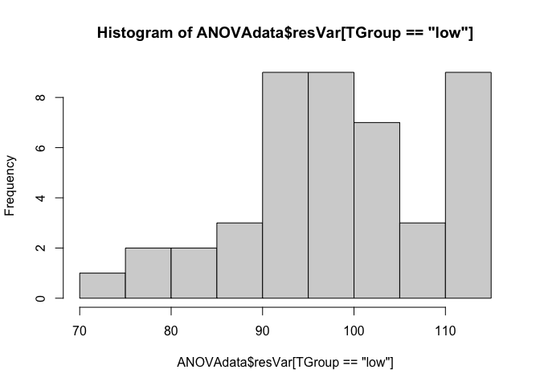

```r
hist(ANOVAdata$resVar[TGroup == "low"])
```

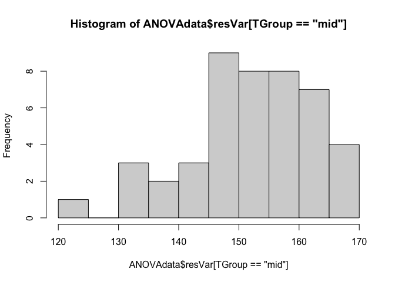

```r
hist(ANOVAdata$resVar[TGroup == "mid"]) #less normally distributed than I'd expect
```

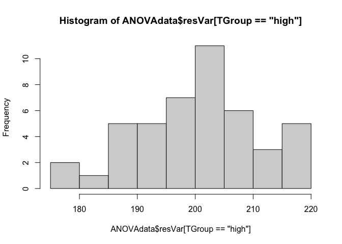

```r
hist(ANOVAdata$resVar[TGroup == "high"])
```

##### Question 4: analyze the data

ANOVA + boxplot

```r
ANOVAmodel <- aov(resVar~TGroup,data=ANOVAdata) # ANOVA analysis
boop <- summary(ANOVAmodel) # put the summary into an object
boop # take a peek
```

```
##              Df Sum Sq Mean Sq F value Pr(>F)
## TGroup        2 236608  118304    1126 <2e-16 ***
## Residuals   132  13872     105
## ---
## Signif. codes:  0 '***' 0.001 '**' 0.01 '*' 0.05 '.' 0.1 ' ' 1
```

```r
aggregate(resVar~TGroup,data=ANOVAdata,FUN=mean) # print the means for low, mid, high
```

```
##   TGroup    resVar
## 1    low  98.02896
## 2    mid 151.91650
## 3   high 200.53094
```

```r
unlist(boop) # to make it easier to extract the ones we want
```

```
##          Df1          Df2      Sum Sq1      Sum Sq2     Mean Sq1     Mean Sq2
## 2.000000e+00 1.320000e+02 2.366083e+05 1.387238e+04 1.183041e+05 1.050938e+02
##     F value1     F value2      Pr(>F)1      Pr(>F)2
## 1.125700e+03           NA 1.155769e-83           NA
```

```r
ANOVAsum <- list(Fval=unlist(boop)[7],probF=unlist(boop)[9]) # F statistic & p-value
ANOVAsum
```

```
## $Fval
## F value1
##   1125.7
##
## $probF
##      Pr(>F)1
## 1.155769e-83
```

P-value of the ANOVA is *very* significant  
Now, the boxplot:

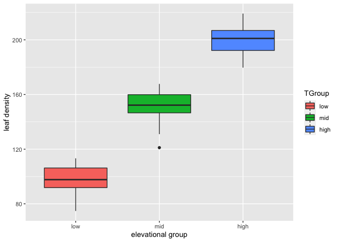

```r
library(ggplot2) # load ggplot

ANOVAplot <- ggplot(data=ANOVAdata,aes(x=TGroup,y=resVar,fill=TGroup)) +
  geom_boxplot() +
  xlab("elevational group") +
  ylab("leaf density")

print(ANOVAplot)
```

```r
ggsave(filename = "ANOVA_HW8.pdf", plot = ANOVAplot, device = "pdf") #in case I want to look at this later
```

##### Question 5: running the analysis multiple times

copying streamlined code down below

```r
nGroup <- 3
nName <- c("low","mid","high")
nSize <- c(45,45,45)
nMean <- c(100,150,200)
nSD <- c(10,10,10)
ID <- 1:(sum(nSize))
resVar <- c(rnorm(n=nSize[1],mean=nMean[1],sd=nSD[1]),
            rnorm(n=nSize[2],mean=nMean[2],sd=nSD[2]),
            rnorm(n=nSize[3],mean=nMean[3],sd=nSD[3]))
TGroup <- factor(x=rep(nName,nSize), levels=nName, ordered= is.ordered(nName))
ANOVAdata <- data.frame(ID,TGroup,resVar)
ANOVAmodel <- aov(resVar~TGroup,data=ANOVAdata)
boop <- summary(ANOVAmodel)
aggregate(resVar~TGroup,data=ANOVAdata,FUN=mean)
```

```
##   TGroup    resVar
## 1    low  99.42827
## 2    mid 150.99094
## 3   high 202.20634
```

```r
unlist(boop)
```

```
##          Df1          Df2      Sum Sq1      Sum Sq2     Mean Sq1     Mean Sq2
## 2.000000e+00 1.320000e+02 2.376759e+05 1.249609e+04 1.188379e+05 9.466733e+01
##     F value1     F value2      Pr(>F)1      Pr(>F)2
## 1.255322e+03           NA 1.268638e-86           NA
```

```r
ANOVAsum <- list(Fval=unlist(boop)[7],probF=unlist(boop)[9])
ANOVAsum
```

```
## $Fval
## F value1
## 1255.322
##
## $probF
##      Pr(>F)1
## 1.268638e-86
```

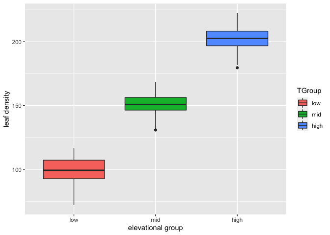

```r
ANOVAplot <- ggplot(data=ANOVAdata,aes(x=TGroup,y=resVar,fill=TGroup)) +
  geom_boxplot() +
  xlab("elevational group") +
  ylab("leaf density")
print(ANOVAplot)
```

After running it several times, I observe that the results are not that different with each run.